# **Simple Blackjack Agent**

```python
        Returns:
            Probability of busting
        """
        # If player has a soft hand, they can't bust with one card
        if has_usable_ace:
            return 0.0

        # Calculate which cards cause a bust
        bust_threshold = 21 - player_total

        # Get card probabilities
        card_probs = self._calc_card_probabilities()

        # Sum probabilities of cards that would cause a bust
        bust_prob = sum(prob for card, prob in card_probs.items() if card > bust_threshold)

        return bust_prob

    def _calc_expected_value(self, player_total, dealer_card, has_usable_ace, action):
        """Calculate expected value of taking an action in the current state.

        Args:
            player_total: Current player hand total
            dealer_card: Dealer's visible card
            has_usable_ace: Whether player has a usable ace
            action: 0 for stand, 1 for hit

        Returns:
            Expected value (average reward) for taking this action
        """
        # Cache key for memorization
        cache_key = f"ev_{player_total}_{dealer_card}_{has_usable_ace}_{action}"
        if cache_key in self.expected_value_cache:
            return self.expected_value_cache[cache_key]

        # Case 1: Player stands
        if action == 0:
            # Calculate dealer's final hand probabilities
            dealer_probs = self._calc_dealer_final_probabilities(dealer_card)

            # Calculate expected value
            ev = 0.0

            for dealer_total, prob in dealer_probs.items():
                # Dealer busts
                if dealer_total > 21:
                    ev += prob * 1.0  # Player wins
                # Player wins
                elif player_total > dealer_total:
                    ev += prob * 1.0
                # Push (tie)
                elif player_total == dealer_total:
                    ev += prob * 0.0
                # Dealer wins
                else:
                    ev += prob * (-1.0)

        # Case 2: Player hits
        else:
            # Get card probabilities
            card_probs = self._calc_card_probabilities()

            # Calculate expected value for each possible card drawn
            ev = 0.0

            for card, prob in card_probs.items():
                new_total = player_total + card
                new_has_ace = has_usable_ace

                # Handle ace logic
                if card == 1:  # Ace
                    if new_total + 10 <= 21:  # Can use ace as 11
                        new_total += 10
                        new_has_ace = True

                # Convert soft 21+ by making ace worth 1
                if new_has_ace and new_total > 21:
                    new_total -= 10
                    new_has_ace = False

                # If player busts, lose immediately
                if new_total > 21:
                    ev += prob * (-1.0)

                # If player gets 21, assume it's a win (simplified)
                elif new_total == 21:
                    ev += prob * 1.0

                # Otherwise, recursively calculate best action's expected value
                else:
                    # Calculate expected value of standing
                    stand_ev = self._calc_expected_value(new_total, dealer_card, new_has_ace, 0)

                    # Calculate expected value of hitting again
                    hit_ev = self._calc_expected_value(new_total, dealer_card, new_has_ace, 1)

                    # Take the better action
                    best_ev = max(stand_ev, hit_ev)
                    ev += prob * best_ev

        # Cache and return
        self.expected_value_cache[cache_key] = ev
        return ev

    def step(self, state):
        """Return action based on MDP calculations."""
        player_score, dealer_card, has_usable_ace = self._extract_state_info(state)

        # Calculate expected value of each action
        stand_ev = self._calc_expected_value(player_score, dealer_card, has_usable_ace, 0)
        hit_ev = self._calc_expected_value(player_score, dealer_card, has_usable_ace, 1)

        # Choose action with higher expected value
        if stand_ev >= hit_ev:
            return 0  # Stand
        else:
            return 1  # Hit

    def eval_step(self, state):
        """Same as step for evaluation but returns tuple for compatibility."""
        return self.step(state), None

class MDPCardCountingAgent(MDPBasicStrategyAgent):
    """Enhanced MDP-based agent that incorporates card counting."""

    def __init__(self, num_actions=2):
        super().__init__(num_actions)

        # Card counting variables
        self.running_count = 0
        self.cards_seen = 0
        self.decks = 1  # Default to 1 deck
        self.seen_cards = {}  # Track seen cards for better probability calculations

    def step(self, state):
        """Take action using MDP with card counting adjustments."""
        # Update card count based on visible cards
        self._update_card_count(state)

        player_score, dealer_card, has_usable_ace = self._extract_state_info(state)

        # Calculate true count
        remaining_decks = max(self.decks - self.cards_seen / 52, 0.5)
        true_count = self.running_count / remaining_decks

        # Calculate expected values considering current count
        stand_ev = self._calc_expected_value(player_score, dealer_card, has_usable_ace, 0)
        hit_ev = self._calc_expected_value(player_score, dealer_card, has_usable_ace, 1)

        # Adjust expected values based on count (simplified adjustment)
        if true_count > 0:  # Positive count favors the player
            stand_ev += 0.01 * true_count  # Slight boost to standing EV
        elif true_count < 0:  # Negative count favors the dealer
            hit_ev += 0.01 * abs(true_count)  # Slight boost to hitting EV

        # Choose action with higher expected value
        if stand_ev >= hit_ev:
            return 0  # Stand
        else:
            return 1  # Hit
```

```python
    def eval_step(self, state):
        """Same as step for evaluation but returns tuple for compatibility."""
        return self.step(state), None

    def _update_card_count(self, state):
        """Update card counting based on visible cards (Hi-Lo system)."""
        try:
            # Extract dealer's card
            _, dealer_card, _ = self._extract_state_info(state)

            # Update seen cards dictionary
            if dealer_card not in self.seen_cards:
                self.seen_cards[dealer_card] = 0
            self.seen_cards[dealer_card] += 1

            # Hi-Lo counting: 2-6 (+1), 7-9 (0), 10-A (-1)
            if 2 <= dealer_card <= 6:
                self.running_count += 1
            elif dealer_card >= 10 or dealer_card == 1:  # 10-A
                self.running_count -= 1

            self.cards_seen += 1

            # Reset count if we've seen too many cards (deck reshuffled)
            if self.cards_seen > 52 * self.decks * 0.75:  # 75% of cards seen
                self.running_count = 0
                self.cards_seen = 0
                self.seen_cards = {}

        except Exception as e:
            # Silently continue if card counting fails
            pass

    def _calc_card_probabilities(self, cards_seen=None):
        """Override to use actually seen cards for better probability estimates."""
        if cards_seen is None:
            cards_seen = self.seen_cards

        return super()._calc_card_probabilities(cards_seen)

# Test MDP-based agents
def test_mdp_agents():
    mdp_basic = MDPBasicStrategyAgent()
    mdp_counting = MDPCardCountingAgent()

    # Test MDP Basic Agent
    print("Testing MDP Basic Strategy Agent...")
    env.set_agents([mdp_basic])
    for _ in range(5):
        _, payoffs = env.run(is_training=False)
        print(f"Game payoff: {payoffs}")

    # Quick evaluation
    reward = tournament(env, 1000)[0]
    print(f"MDP Basic Strategy average reward: {reward}")

    # Test MDP Card Counting Agent
    print("\nTesting MDP Card Counting Agent...")
    env.set_agents([mdp_counting])
    for _ in range(5):
        _, payoffs = env.run(is_training=False)
        print(f"Game payoff: {payoffs}")

    # Quick evaluation
    reward = tournament(env, 1000)[0]
    print(f"MDP Card Counting average reward: {reward}")

    return mdp_basic, mdp_counting
```

# **5. Model-Free Q-Learning Agent**

**Purpose**: Implements a model-free reinforcement learning agent using Q-learning.

- Maintains a state-action value table (Q-table)
- Uses epsilon-greedy exploration during training
- Updates Q-values based on observed rewards and transitions
- Includes functions to train the agent and display learned values

```python
class BlackjackAgent:
    """Q-learning reinforcement learning agent using Q-learning."""

    def __init__(self, env_instance):
        self.env = env_instance
        self.q_table = {}

        # Learning parameters
        self.alpha = 0.1  # Learning rate
        self.discount_factor = 0.95
        self.epsilon = 1.0  # Exploration rate
        self.epsilon_decay = 0.995  # Epsilon decay rate for better exploration-exploitation balance
        self.min_epsilon = 0.01  # Minimum exploration rate

        # Statistics
        self.training_iterations = 0

    def get_state_key(self, state):
        """Convert state to a hashable key for the Q-table."""
        try:
            # Try to access elements (player_score, dealer_card) and (usable_ace ==> 1)
            player_score, dealer_card, usable_ace = state

            # Return a tuple that can be used as a dictionary key
            return (player_score, dealer_card, 1 if usable_ace else 0)
        except:
            # If the state structure is not what we expect, hash all of the state
            return hash(str(state))

    def choose(self, state):
        """Choose an action using epsilon-greedy strategy."""
        state_key = self.get_state_key(state)

        # Initialize Q-values for this state if not seen before
        if state_key not in self.q_table:
            self.q_table[state_key] = {a: 0.0 for a in range(self.env.action_space.n)}

        # Epsilon-greedy action selection
        if np.random.random() < self.epsilon:
            action = np.random.randint(0, self.env.action_space.n)
        else:
            action = max(self.q_table[state_key], key=self.q_table[state_key].get)

        return action

    def act(self, state):
        """Choose policy for evaluation."""
        state_key = self.get_state_key(state)

        # Initialize Q-values for this state if not seen before
        if state_key not in self.q_table:
            self.q_table[state_key] = {a: 0.0 for a in range(self.env.action_space.n)}

        # Greedy action with highest Q-value
        action = max(self.q_table[state_key], key=self.q_table[state_key].get)

        return action, None

    def feed(self, state, action, reward, next_state, done = False):
        """Learn based on experience."""
        try:
            state_key = self.get_state_key(state)

            # Initialize Q-values if needed
            if state_key not in self.q_table:
                self.q_table[state_key] = {a: 0.0 for a in range(self.env.action_space.n)}

            # Calculate target
            if done:
                target = reward
            else:
                next_state_key = self.get_state_key(next_state)

                # Initialize next state's Q-values if needed
                if next_state_key not in self.q_table:
                    self.q_table[next_state_key] = {a: 0.0 for a in range(self.env.action_space.n)}

                # Get the maximum Q-value for the next state
                target = reward + self.discount_factor * max(self.q_table[next_state_key].values())

            # Update Q-value
            self.q_table[state_key][action] = (1 - self.alpha) * self.q_table[state_key][action] + self.alpha * target

            # Decay epsilon for better exploration-exploitation balance
            if done:
                self.epsilon = max(self.min_epsilon, self.epsilon * self.epsilon_decay)

            self.training_iterations += 1

        except Exception as e:
            print("Error in feed function of update fails")
            print(e)
            pass

# Function to train the Q-learning agent
def train_agent(env, episodes=5000):
    q_agent = BlackjackAgent(env)

    rewards = []

    print(f"Training Q-learning agent for {episodes} episodes...")

    for episode in range(episodes):
        state, info = env.reset()
        total_reward = 0
        done = False

        # Quick evaluation every 1000 episodes
        if episode % 1000 == 0:
            rewards.append(evaluate_agent(env, q_agent))
            print(f"Episode {episode}/{episodes}")
            print(f"Current average reward: {rewards[-1]}")

        while not done:
            # Choose action using epsilon-greedy
            action = q_agent.choose(state)

            # Take action in environment
            next_state, reward, terminated, truncated, info = env.step(action)
            done = terminated or truncated

            # Feed experience to agent for learning
            q_agent.feed(state, action, reward, next_state, done)

            # Update state and reward
            state = next_state
            total_reward += reward

    # Final evaluation
    final_reward = evaluate_agent(env, q_agent)
    print(f"Q-Learning final average reward: {final_reward}")

    # Display some learned Q-values
    print("Sample of learned Q-values (player_score, dealer_card, usable_ace):")
    print("Total states in Q-table:", len(q_agent.q_table))

    # Print some interesting Q-values for visual inspection
    print(f"(20, 10, False): A Q-value indicating what to do with 20 vs dealer 10")
    print(f"(16, 10, False): A Q-value indicating what to do with soft 16 vs dealer 10")
    print(f"(12, 6, False): A Q-value indicating what to do with hard 12 vs dealer 6")
    print(f"(11, 6, False): A Q-value indicating when to double down")

    # Print some interesting states
    for state_key in sorted(list(q_agent.q_table.keys()))[:10]:
        if state_key in q_agent.q_table:
            action = max(q_agent.q_table[state_key], key=q_agent.q_table[state_key].get)
            action_name = "Hit" if action == 1 else "Stick"
            print(f"State {state_key}: Q-values {q_agent.q_table[state_key]} -> {action_name}")

    print(f"Total states in Q-table: {len(q_agent.q_table)}")

    return q_agent

# Function to evaluate the agent's performance
def evaluate_agent(env, agent, episodes=100):
    total_reward = 0

    for _ in range(episodes):
        state, info = env.reset()
        done = False
        episode_reward = 0

        while not done:
            action, _ = agent.act(state)
            next_state, reward, terminated, truncated, info = env.step(action)
            done = terminated or truncated
            episode_reward += reward
            state = next_state

        total_reward += episode_reward

    return total_reward / episodes
```

# **6. Hybrid Agent**

**Purpose**: Implements the hybrid agent that combines all three approaches.

- Integrates basic strategy, card counting, and Q-learning
- Uses a decision rule to switch between strategies based on confidence
- Early in training: relies more on model-based approach
- With significant count: uses model-free approach
- Otherwise uses card counting enhanced basic strategy

```python
class HybridBlackjackAgent:
    """Combines model-based strategy with model-free learning and card counting."""

    def __init__(self):
        self.use_raw = False

        # Initialize component agents without arguments
        self.basic_strategy = BasicStrategyAgent()
        self.card_counting = CardCountingAgent()
        env = gym.make('Blackjack-v1')
        self.q_learning = BlackjackAgent(env)

        # For direct access to card counting state
        self.running_count = 0
        self.cards_seen = 0
        self.count_threshold = 2

    def _extract_state_info(self, state):
        """Extract player score, dealer card, and usable ace from state."""
        try:
            player_score, dealer_card, usable_ace = state
            return player_score, dealer_card, usable_ace
        except:
            # Use a default fallback if extraction fails
            return 15, 10, False

    def update_card_count(self, state):
        """Update internal card count based on dealer's visible card."""
        player_score, dealer_card, has_usable_ace = self._extract_state_info(state)

        # Hi-Lo counting: 2-6 (+1), 7-9 (0), 10-A (-1)
        if 2 <= dealer_card <= 6:
            self.running_count += 1
        elif dealer_card >= 10 or dealer_card == 1:  # Ace is often represented as 1
            self.running_count -= 1

        self.cards_seen += 1

    def step(self, state):
        """Take action using the appropriate strategy based on confidence."""
        # Update our internal card count
        self.update_card_count(state)

        # Calculate true count
        true_count = self.running_count / max(1, self.cards_seen / 52)

        # Decision logic for which strategy to use
        if self.q_learning.training_iterations < 5000:
            # Early in training, rely on model-based approach
            action, _ = self.card_counting.act(state)
            return action
        elif abs(true_count) >= self.count_threshold:
            # When count is significant, use model-free approach
            return self.q_learning.act(state)[0]
        else:
            # Default to card counting enhanced basic strategy
            action, _ = self.card_counting.act(state)
            return action

    def act(self, state):
        """Same as step but returns tuple for compatibility."""
        return self.step(state), None

    def eval_step(self, state):
        """Same as step for evaluation but returns tuple for compatibility."""
        return self.step(state), None

    def feed(self, state, action, reward, next_state, done=False):
        """Feed transition to the Q-learning component."""
        # Only the Q-learning component learns from experience
        self.q_learning.feed(state, action, reward, next_state, done)
```

# **7. Evaluation and Comparison**

**Purpose**: Provides functions to evaluate and compare all agent types.

- Evaluates each agent over a set number of games
- Compares their performance in terms of average reward
- Analyzes how different agents behave on specific hands
- Determines which agent performs best overall

```python
def evaluate_all_agents(agents_dict, num_games=2000):
    """Evaluate and compare all agents.

    Args:
        agents_dict: Dictionary of agent names to agent objects
        num_games: Number of games to evaluate each agent on
    """
    print(f"\nEvaluating all agents ({num_games} games each):")

    results = {}
    for name, agent in agents_dict.items():
        env.set_agents([agent])
        reward = tournament(env, num_games)[0]
        results[name] = reward
        print(f"{name.capitalize()} Agent average reward: {reward}")

    # Find the best agent
    best_agent = max(results.items(), key=lambda x: x[1])
    print(f"\nBest performing agent: {best_agent[0].capitalize()} with reward {best_agent[1]}")

    return results

def compare_specific_hands(agents_dict):
    """Compare how different agents perform on specific hands."""
    # Define some interesting hands to compare
    test_hands = [
        # (player_score, dealer_card, usable_ace)
        (16, 10, False),  # Tough hand vs. strong dealer
        (12, 3, False),   # Borderline hand vs. weak dealer
        (18, 9, True),    # Soft 18 vs. medium dealer
        (15, 7, False),   # Medium hand vs. medium dealer
    ]

    print("\nComparing agent decisions on specific hands:")
    print("Format: (player_score, dealer_card, usable_ace) -> action")

    for hand in test_hands:
        print(f"\nHand: {hand}")

        # Create a mock state with the hand information
        mock_state = np.array([hand[0], hand[1], 1 if hand[2] else 0])

        for name, agent in agents_dict.items():
            if hasattr(agent, 'step'):
                try:
                    action = agent.step(mock_state)
                    action_name = "Stand" if action == 0 else "Hit"
                    print(f"{name.capitalize()}: {action_name}")
                except Exception as e:
                    print(f"{name.capitalize()}: Error ({e})")
```

# **8. Running the Experiment**

```python
def run_full_experiment_with_mdp(training_episodes=5000, eval_games=1000):
    """Run the complete experiment with all agent types, including MDP-based agents and Hybrid."""
    # Create environment
    env = gym.make('Blackjack-v1')

    # Create random agent as baseline
    random_agent = RandomAgent(num_actions=env.action_space.n)

    # Create basic strategy agents (both traditional and MDP-based)
    basic_agent = BasicStrategyAgent()
    mdp_basic_agent = MDPBasicStrategyAgent()

    # Create card counting agents (both traditional and MDP-based)
    counting_agent = CardCountingAgent()
    mdp_counting_agent = MDPCardCountingAgent()

    # Train Q-learning agent
    print("Training Q-learning agent...")
    q_agent = BlackjackAgent(env)

    # Train the agent
    for episode in range(training_episodes):
        state, info = env.reset()
        done = False

        if episode % 1000 == 0:
            print(f"Episode {episode}/{training_episodes}")
            print(f"Current average reward: {evaluate_agent(env, q_agent, 100)}")

        while not done:
            action = q_agent.choose(state)
            next_state, reward, terminated, truncated, info = env.step(action)
            done = terminated or truncated
            q_agent.feed(state, action, reward, next_state, done)
            state = next_state

    # Final evaluation for Q-learning
    q_reward = evaluate_agent(env, q_agent, eval_games)
    print(f"Q-Learning final average reward: {q_reward}")
    print(f"Total states in Q-table: {len(q_agent.q_table)}")

    # Train hybrid agent
    print("Training hybrid agent...")
    hybrid_agent = HybridBlackjackAgent()

    # Train the hybrid agent
    for episode in range(training_episodes):
        state, info = env.reset()
        done = False

        if episode % 1000 == 0:
            print(f"Episode {episode}/{training_episodes}")
            current_reward = evaluate_agent(env, hybrid_agent, 100)
            print(f"Current average reward: {current_reward}")

        while not done:
            action = hybrid_agent.step(state)
            next_state, reward, terminated, truncated, info = env.step(action)
            done = terminated or truncated
            hybrid_agent.feed(state, action, reward, next_state, done)
            state = next_state

    # Final evaluation for Hybrid agent
    hybrid_reward = evaluate_agent(env, hybrid_agent, eval_games)
    print(f"Hybrid agent final average reward: {hybrid_reward}")

    # Store all agents in a dictionary for evaluation
    agents = {
        "random": random_agent,
        "basic": basic_agent,
        "mdp_basic": mdp_basic_agent,
        "counting": counting_agent,
        "mdp_counting": mdp_counting_agent,
        "q_learning": q_agent,
        "hybrid": hybrid_agent
    }

    # Evaluate all agents
    print("Evaluating all agents...")
    results = evaluate_all_agents(agents, env, eval_games)

    # Compare decisions on specific hands
    print("Comparing decisions on specific hands:")
    compare_specific_hands(agents)

    return agents, results
```

[output not shown]

[output cut: 24 more lines]

```
Hand: hard 15 vs. dealer 7
Basic Strategy: Hit
MDP Basic: Hit
Card Counting: Hit
MDP Counting: Hit
Q-learning: Hit

Final Performance Results:
basic average reward: -0.045
mdp_basic average reward: -0.052
mdp_counting average reward: -0.056
counting average reward: -0.070
q_learning average reward: -0.104
hybrid average reward: -0.110
random average reward: -0.404
```

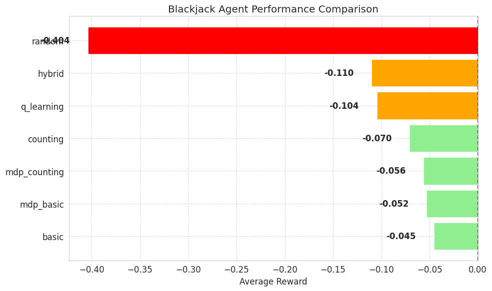

```python
# Run the evaluation
if __name__ == "__main__":
    # Run with fewer training episodes for faster results
    agents, results = run_full_experiment_with_mdp(training_episodes=5000, eval_games=2000)

    print("\nFinal Performance Results:")
    # Sort agents by performance (best to worst)
    sorted_results = sorted(results.items(), key=lambda x: x[1], reverse=True)
    for name, reward in sorted_results:
        print(f"{name} average reward: {reward:.3f}")

    # Create a visualization of the results
    agent_names = [name for name, _ in sorted_results]
    agent_rewards = [reward for _, reward in sorted_results]

    plt.figure(figsize=(10, 6))
    bars = plt.barh(agent_names, agent_rewards)

    # Color bars based on performance
    for i, bar in enumerate(bars):
        if agent_rewards[i] > 0:
            bar.set_color('green')
        elif agent_rewards[i] > -0.1:
            bar.set_color('lightgreen')
        elif agent_rewards[i] > -0.2:
            bar.set_color('orange')
        else:
            bar.set_color('red')

    # Add value labels to the bars
    for i, bar in enumerate(bars):
        plt.text(
            bar.get_width() + 0.01 if bar.get_width() >= 0 else bar.get_width() - 0.05,
            bar.get_y() + bar.get_height()/2,
            f'{agent_rewards[i]:.3f}',
            va='center',
            fontweight='bold'
        )

    plt.title('Blackjack Agent Performance Comparison')
    plt.xlabel('Average Reward')
    plt.axvline(x=0, color='black', linestyle='--', alpha=0.7)
    plt.grid(True, linestyle='--', alpha=0.7)
    plt.tight_layout()
    plt.show()
```